# Build a deep learning model to classify the Yoga poses 107 dataset - https://www.kaggle.com/datasets/arrowe/yoga-poses-dataset-107

# a) Perform exploratory data analysis and data cleaning as necessary.

under this folder C:\Users\gongl1\Desktop\Advanced Computer Vision_Pujari\Assignment2\archive (18)\107 yoga poses, I have 3 sub folders - test, train, val, each has 107 subfolders that representing 107 yoga poses. In each subfolder, it includes PNG images showing a certain yoga pose. I want to Build a deep learning model to classify the Yoga poses 107 dataset. First, Perform exploratory data analysis and data cleaning as necessary.

# Load the Data

```python
import os
from pathlib import Path
from PIL import Image
import matplotlib.pyplot as plt

# Define the paths
base_dir = Path("C:/Users/gongl1/Desktop/Advanced Computer Vision_Pujari/Assignment2/archive (18)/107 yoga poses")
train_dir = base_dir / "train"
val_dir = base_dir / "val"
test_dir = base_dir / "test"

# Function to load images
# Recursively goes through the given folder.
# Reads and loads images from each subfolder.
# Assigns the name of the subfolder as the label for each image.
# Returns two lists: one with the image objects and one with the corresponding labels.
def load_images_from_folder(folder):
    images = []
    labels = []
    for label_dir in os.listdir(folder):
        if not os.path.isdir(os.path.join(folder, label_dir)):
            continue
        label = label_dir
        # The function iterates over each item in the specified folder using os.listdir(folder).
        # For each item (label_dir), it checks if it is a directory using os.path.isdir(os.path.join(folder, label_dir)).
        # If the item is not a directory, it skips to the next iteration with continue.
        # If the item is a directory, it assigns the directory name to the variable label, which will be used as the label for the images within that directory.

        for filename in os.listdir(os.path.join(folder, label_dir)):
            img_path = os.path.join(folder, label_dir, filename)
            try:
                img = Image.open(img_path)
                images.append(img)
                labels.append(label)
            except:
                print(f"Error loading image: {img_path}")
        # For each label_dir, the function iterates over the files inside that directory.
        # It constructs the full path to each image file using os.path.join(folder, label_dir, filename).
        # It then tries to open the image using Image.open(img_path).
        # If the image is successfully opened, it is appended to the images list, and the corresponding label is appended to the labels list.
        # If there is an error opening the image (e.g., the file is corrupted or not an image), it catches the exception and prints an error message indicating the problematic file.

    return images, labels
    # After iterating through all the subfolders and files, the function returns two lists: images (containing the loaded image objects) and labels (containing the corresponding labels for each image).


# Load data
train_images, train_labels = load_images_from_folder(train_dir)
val_images, val_labels = load_images_from_folder(val_dir)
test_images, test_labels = load_images_from_folder(test_dir)

print(f"Loaded {len(train_images)} training images, {len(val_images)} validation images, and {len(test_images)} test images.")
```

```
Loaded 4150 training images, 1157 validation images, and 687 test images.
```

```python
# test_images
```

```python
# test_labels
```

# Explore the Data

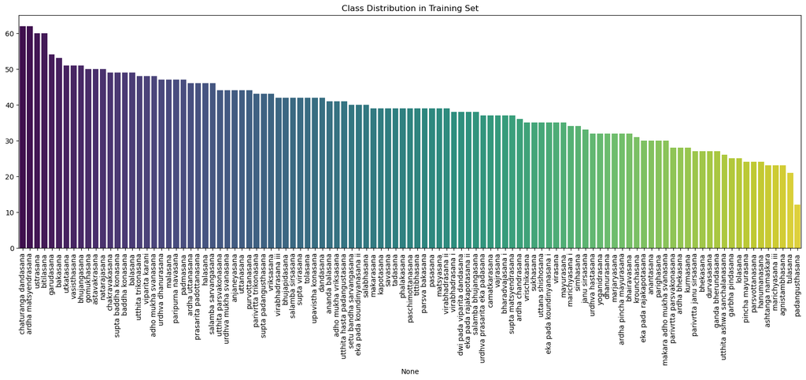

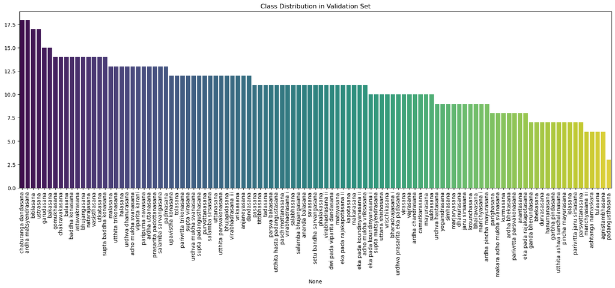

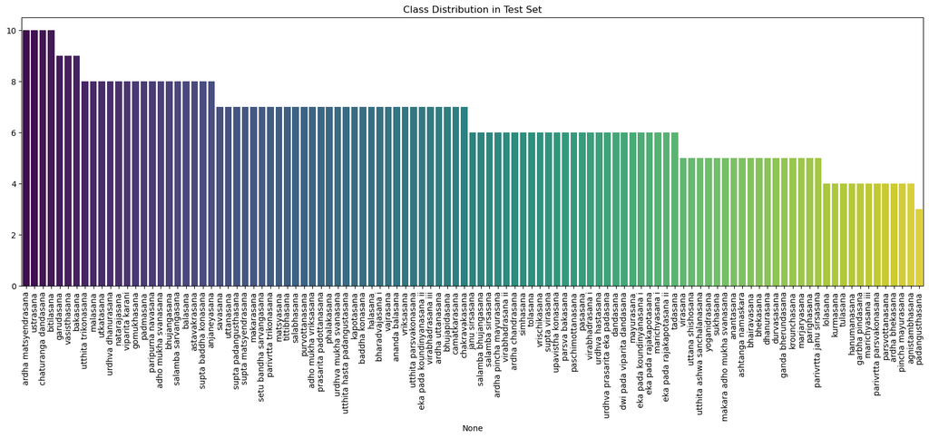

```python
import pandas as pd
import seaborn as sns

# Function to get distribution of classes
def get_class_distribution(labels):
    return pd.Series(labels).value_counts()

# Get distributions
train_dist = get_class_distribution(train_labels)
val_dist = get_class_distribution(val_labels)
test_dist = get_class_distribution(test_labels)

# Plot distributions
plt.figure(figsize=(20, 6))
sns.barplot(x=train_dist.index, y=train_dist.values, palette="viridis")
plt.title("Class Distribution in Training Set")
plt.xticks(rotation=90)
plt.show()

plt.figure(figsize=(20, 6))
sns.barplot(x=val_dist.index, y=val_dist.values, palette="viridis")
plt.title("Class Distribution in Validation Set")
plt.xticks(rotation=90)
plt.show()

plt.figure(figsize=(20, 6))
sns.barplot(x=test_dist.index, y=test_dist.values, palette="viridis")
plt.title("Class Distribution in Test Set")
plt.xticks(rotation=90)
plt.show()
```